# [Kaggle] Overwatch Analysis

THE-R

2018-04-15

[figure not shown]

```r
#load packages and csv file
library(ggplot2)
library(dplyr)
library(gridExtra)
library(fmsb)
library(ggthemes)
library(ggridges)
library(RColorBrewer)
library(grid)
library(gridExtra)
library(ggrepel)
library(GGally)
library(gplots)
library(ggdendro)
library(factoextra)
library(NbClust)
library(corrplot)
library(corrgram)
```

*warning: according the data the dataset was posted, I estimated it to correspond to **patch 1.8.0.2**(February 28, 2017), so the data here may not reflect the **actual** characteristics of the Heroes*

# Motivation

There are 4 types of classes in Overwatch ([wikia](http://overwatch.wikia.com/wiki/Role)) :

- **Offense**: main objective is to scout the area, harass the opposing team, and press the objective. Heroes classified as offense generally have high damage weapons and abilities and lower health pools. They are usually excellent duelists with high mobility and good burst or sustained damage.
- **Defense**: main objective is to guard locations and establish a front. They may have long range weapons or the ability to create turrets, and excel at area denial.
- **Support**: main objective of support is to heal, buff and provide utility. Support heroes boost the overall performance of their team by increasing their survivability, speed, and damage output.
- **Tank**: they specialize in protecting allies, disrupting enemies, and occupying the front line. They have high survivability and abilities that protect themselves and others with shields and crowd control.

The current data has the abilities list per character:

- the number of abilities is not the same per character so I will take the `median` when grouping per character(most of the time there are 2 abilities/character but sometimes there are more than 2 so taking the median rather than the mean is *safer*)
- We can try to `cluster` the Heroes according their abilities and infer to which class they belong.

# Data preparation

Some data cleaning / features transformations below.

- create column with name of each heroes based on the attack / ability column.
  - small tweak for `Torbj`
- convert the `Life` column to numeric.
  - there are few cases, like `100/300` that need some regexp to extract the mean value.
- add the gender: not really useful for clustering but still interesting to add as feature.
- there is 1 row for which I could not find the `Heroes_name`(the one with name `melee` so I removed this line).

```r
#load data
df<-read.csv('../../data/Overwatch_edopic.csv',sep=',',stringsAsFactors=F)

#make list of all heroes name
heroes_name<-c('Ana','Bastion','D.va','Junkrat','Genji','Hanzo','Lucio','McCree','Mei','Mercy','Pharah','Reaper','Reinhardt','Roadhog','Soldier','Sombra','Symmetra','Torbj','Tracer','Widowmaker','Winston','Zarya','Zeny','Torretta')

#loop over the Heroes column to extract the name of the character
x <- vector(mode="character", length=nrow(df))
for(i in 1:length(heroes_name)){
    if(heroes_name[i] == 'Torretta'){
        temp<-grep(heroes_name[i],df$Heroes)
        for(k in 1:length(temp)){
            x[temp[k]]<-'Torbj'
        }
    } else {
        check<-grep(heroes_name[i],df$Heroes)
        for(j in 1:length(check)){
            x[check[j]]<-heroes_name[i]
            }
        }
}
#make new column with Heroes name
df$Heroes_name<-x

#convert Life to numeric
convertLife<-function(x){
    if(grepl('\\/',x)==TRUE){
        res<-(as.numeric(strsplit(x,'/')[[1]][1]) + as.numeric(strsplit(x,'/')[[1]][2]))/2.
    }
    else{
        res<-as.numeric(x)
    }
    return(res)
}
df$Life<-sapply(df$Life, convertLife)

#make list of gender
inferGender<-function(x){
  if(x %in% c('Ana','D.va','Mei','Mercy','Pharah','Sombra','Symmetra','Tracer','Widowmaker','Zarya')){
    return('female')
    }
  else if(x %in% c('Junkrat','Genji','Hanzo','Lucio','McCree','Reaper','Reinhardt','Roadhog','Soldier','Torbj')){
    return('male')
    }
  else if(x %in% c('Bastion','Zeny')){
    return('robot')
  }
  else if(x %in% c('Winston')){
    return('animal')
  }
  else return('other')
}
df$gender<-sapply(df$Heroes_name, inferGender)

#clean row with empty name
df<-df %>%dplyr::filter(Heroes_name!="")

#add color per gender
mycat<-c('female','male','robot','animal','other')
mycols<-c("#FF7F00","#1F78B4","#E31A1C","#CAB2D6","#999999")
cols<-data.frame('gender'=mycat,'color'=mycols)
df<-left_join(df, cols, by=c('gender'))
```

# Characters’s distribution per ability

The code below is a bit complicated but it’s only because I wanted to make the `median` attributes histograms in 1 loop:

- `listFeatures` is an array of columns index.
- `dplyr::select(Heroes_name,index,color)` selects the name of heroes of the feature column in the loop; it creates a dataframe with 2 columns : `name`, `current_feature` and `color`.
- `summarise_at(1, median) %>% rename_(val=names(.)[3])`: takes the median of the third column(`current_feature`) and renames it `val` so that I can make a plot independently of the real name.

```r
listPlot<-list()
listFeatures<-c(2,3,4,5,6,7,8)
for (i in 1:length(listFeatures)){
    index<-listFeatures[i]
    listPlot[[i]]<-df %>% dplyr::select(Heroes_name,index,color) %>% na.omit() %>%
      dplyr::group_by(Heroes_name,color) %>% dplyr::summarise_at(1,median) %>%
      rename_(val=names(.)[3]) %>%
      ggplot(aes(x=reorder(Heroes_name,val),y=val,fill=color)) +
      geom_histogram(stat='identity',width=.5,color='black',size=.5) +
      coord_flip() + theme_fivethirtyeight() +
      scale_fill_identity() +
      labs(title=colnames(df)[index],
           subtitle='taken as median') +
      theme(axis.text = element_text(size=8),
            plot.title=element_text(face="bold",hjust=.012,vjust=.8,colour="#3C3C3C",size=12),
            plot.subtitle=element_text(size=8, hjust=0, face="italic", color="black"))
}

#make a gender histogram to be used also as color legend
leg<-df %>% group_by(Heroes_name, gender,color) %>% summarize(count = n_distinct(Heroes_name)) %>% group_by(gender,color) %>% summarize(countG=n()) %>%  ggplot(aes(x=gender,y=countG,fill=color)) + geom_bar(stat='identity',color='black',size=.5) +
  scale_fill_identity() + theme_fivethirtyeight() + labs(title='Heroes distribution\nper gender') +
  theme(axis.title = element_blank(),
        plot.title=element_text(face="bold",hjust=.012,vjust=.8,colour="#3C3C3C",size=12),
        plot.subtitle=element_text(size=8, hjust=0, face="italic", color="black"))
```

[figure not shown]

```r
grid.arrange(listPlot[[1]],listPlot[[2]],listPlot[[3]],listPlot[[4]],listPlot[[5]],listPlot[[6]],listPlot[[7]],leg,ncol=4)
```

- **Bastion** seems a vey good character after all: he trusts 3 of the 7 abilities and he’s well ranked in 2 others.
- overall, from my knowledge of the game/characters, this ranking makes sense and somehow agrees with the [wikia](http://overwatch.wikia.com/wiki/Role).

# Analysis

## Look at the raw data

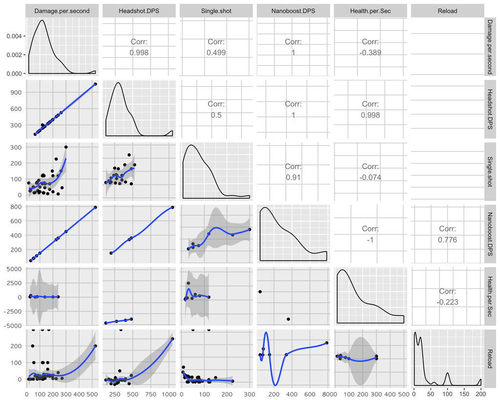

```r
my_fn <- function(data, mapping, method="loess", ...){
      p <- ggplot(data = data, mapping = mapping) +
      geom_point() +
      geom_smooth(method=method, ...) + theme_fivethirtyeight() + theme(axis.text = element_text(size=8))
      p
}
ggpairs(df[,-c(1,7,9,10,11)],lower = list(continuous = my_fn))
```

- some interesting and obvious correlations, for example: `Damage.per.second` vs. `Headshot.DPS`
- `NanoBoost` is one of Ana’s ability to target one ally and shoot an injection to grant them a boost. That player receives a buff for 8 seconds; their attack damage is increased by 50% and gain 50% damage resistance for the duration.
  - the correlation with `Damage.per.second`, or `Headshot.DPS` is linear, which somehow makes sense with the definition of `nanoboost`(increased attack).

## Tank vs. Offense class

### Damage_DPS vs. Life

```r
g1<-df %>%
  dplyr::select(Heroes_name, Damage.per.second,Life,color) %>%
  dplyr::group_by(Heroes_name,color) %>%
  summarize(
    medianDamage = median(Damage.per.second,na.rm=TRUE),
    medianLife = median(Life,na.rm=TRUE)) %>%
  ggplot(aes(x=medianLife, y= medianDamage, fill=color)) + geom_point(size=2) +
  geom_label_repel(aes(label=ifelse(medianLife>400 | medianDamage>200,Heroes_name,"")),size=3,force=1) +
  theme_fivethirtyeight() +
  scale_fill_identity() + theme(
    legend.position='top',
        plot.title=element_text(face="bold",hjust=.012,vjust=.8,colour="#3C3C3C",size=12)) +
  labs(title='median Damage/sec. vs. mean Life')
```

### Headshot_DPS vs. Life

```r
g2<-df %>%
  dplyr::select(Heroes_name, Headshot.DPS,Life,color) %>%
  dplyr::group_by(Heroes_name,color) %>%
  summarize(
    medianHeadshot = median(Headshot.DPS,na.rm=TRUE),
    medianLife = median(Life,na.rm=TRUE)) %>%
  ggplot(aes(x=medianLife, y= medianHeadshot, fill=color)) + geom_point(size=2) +
  geom_label_repel(aes(label=ifelse(medianLife>400 | medianHeadshot>400,Heroes_name,"")),size=3,force=1) +
  theme_fivethirtyeight() +
  scale_fill_identity() + theme(legend.position='top',
        plot.title=element_text(face="bold",hjust=.012,vjust=.8,colour="#3C3C3C",size=12)) +
  labs(title='median Headshot vs. median Life')
```

### Singleshot vs. Life

```r
g3<-df %>%
  dplyr::select(Heroes_name,Single.shot,Life,color) %>%
  dplyr::group_by(Heroes_name,color) %>%
  summarize(
    medianSingleShot = median(Single.shot,na.rm=TRUE),
    medianLife = median(Life,na.rm=TRUE)) %>%
  ggplot(aes(x=medianLife, y= medianSingleShot, fill=color)) + geom_point(size=2) +
  geom_label_repel(aes(label=ifelse(medianLife>400 | medianSingleShot>100,Heroes_name,"")),size=3,force=1) +
  theme_fivethirtyeight() +
  scale_fill_identity() + theme(legend.position='top',
        plot.title=element_text(face="bold",hjust=.012,vjust=.8,colour="#3C3C3C",size=12)) +
  labs(title='median SingleShot vs. median Life')
```

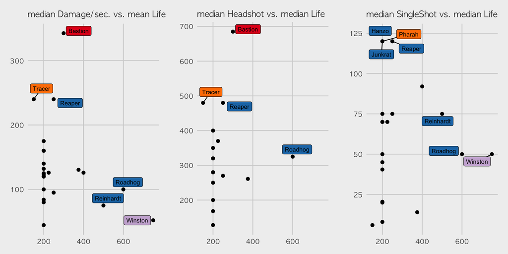

```r
grid.arrange(g1, g2, g3, ncol=3)
```

- again we see some delimitations between characters based on these 3 abilities:
  - high life characters and high `DPS` characters can be grouped into clusters.
- **Reaper** looks a powerfull character: high `DPS` and high `SingleShot` and a good amount of health.

## Radarcharts

For the `radarcharts`, some manipulation was needed:

```r
#repalce Inf by 0
df<-do.call(data.frame,lapply(df, function(x) replace(x, is.infinite(x),NA)))

#group_by Heroes, calculate median for all columns, repalce final NA's, save result in a list
dataPerChar<-list()
for(i in 1:(length(heroes_name)-1)){
  dataPerChar[[i]]<-data.frame(
    df %>% dplyr::filter(Heroes_name==heroes_name[i]) %>%
      dplyr::select_if(is.numeric) %>%
      dplyr::summarise_all(funs(mean(., na.rm = TRUE))) %>%
      dplyr::mutate(Damage.per.second = ifelse(is.na(Damage.per.second), 0, Damage.per.second),
                    Headshot.DPS = ifelse(is.na(Headshot.DPS), 0, Headshot.DPS),
                    Single.shot = ifelse(is.na(Single.shot), 0, Single.shot),
                    Nanoboost.DPS = ifelse(is.na(Nanoboost.DPS), 0, Nanoboost.DPS),
                    Health.per.Sec = ifelse(is.na(Health.per.Sec), 0, Health.per.Sec),
                    Life = ifelse(is.na(Life), 0, Life),
                    Reload = ifelse(is.na(Reload), 0, Reload)))
}

#make a dataframe, add additional features, prepare radarcharts
res<-do.call("rbind",dataPerChar)
res$Heroes_name<-heroes_name[-length(heroes_name)]
res<-left_join(res,df %>% select(Heroes_name,color) %>% distinct(),by='Heroes_name')
min<-rep.int(0,7)
max<- ceiling(apply(res[,1:7], 2, function(x) max(x, na.rm = TRUE)) %>% sapply(as.double)) %>% as.vector
colnames(res)<-c('Damage/sec','Headshot.DPS','SingleShot','Nanoboost.DPS','Health/sec','Life','Reload','Heroes_name','color')
```

[figure not shown]

```r
par(mfrow=c(6,4))
par(mar=c(1,1,1,1))
for(i in 1:nrow(res)){
  curCol<-(col2rgb(as.character(res$color[i]))%>% as.integer())/255
  radarchart(rbind(max,min,res[i,1:7]),
             axistype=2 ,
             pcol=rgb(curCol[1],curCol[2],curCol[3], alpha = 1) ,
             pfcol=rgb(curCol[1],curCol[2],curCol[3],.5) ,
             plwd=2 , cglcol="grey", cglty=1,
             axislabcol="black", caxislabels=seq(0,2000,5), cglwd=0.8, vlcex=0.8,
             title=as.character(res$Heroes_name[i]))
}
```

# Dendograms

The issue with using a dendogram here is that the dataset is quite sparse, because of the `NA` or `Inf` values. One trick however is to :

```r
meanVal<-list()
for(i in 1:(length(heroes_name)-1)){
    meanVal[[i]]<-df %>% filter(Heroes_name==heroes_name[i]) %>% select_if(is.numeric) %>% colMeans(na.rm=T)
}

res<-do.call("rbind",meanVal)
res[!is.finite(res) | is.na(res)] <- -1

rownames(res)<-heroes_name[-length(heroes_name)]
colnames(res)<-c('Damage/sec','Headshot.DPS','SingleShot','Nanoboost.DPS','Health/sec','Life','Reload')

breaks = seq(0,max(res),length.out=1000)
gradient1 = colorpanel( sum( breaks[-1]<=0 ), "green", "black" )
gradient2 = colorpanel( sum( breaks[-1]>0 ), "black", "red" )
hm.colors = c(gradient1,gradient2)
hm.colors[1] = col2hex("gray")

# Clustering and distance measure functions
hclustfunc <- function(x) hclust(x, method="complete")
distfunc <- function(x) dist(x,method="maximum")
```

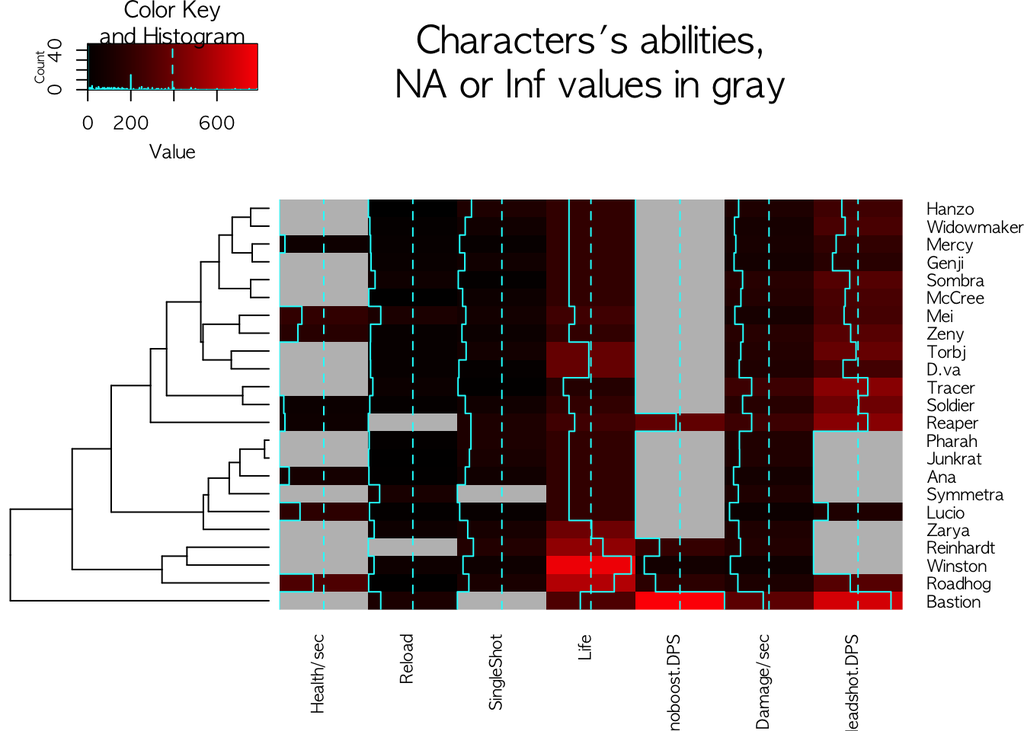

```r
heatmap.2(res,
          scale="none",
          breaks=breaks,
          col=hm.colors,
          na.color="gray",
          dendrogram="row",
          hclust=hclustfunc,
          distfun=distfunc,
          main = "Characters's abilities,\nNA or Inf values in gray",
          cexRow=.8,cexCol=.8)
```

# Clusters

In this section, I’m using the average abilities per character so each character should have either the mean value, or the flagged `-1` is there were `NA` or `Inf`

```r
res_df<-data.frame(res)
res_df$Heroes_name<-rownames(res_df)
res_df<-left_join(res_df,df %>% distinct(Heroes_name, color, gender), by='Heroes_name')
```

## Correlation

Similar to the previous section, we can look at the correlation.

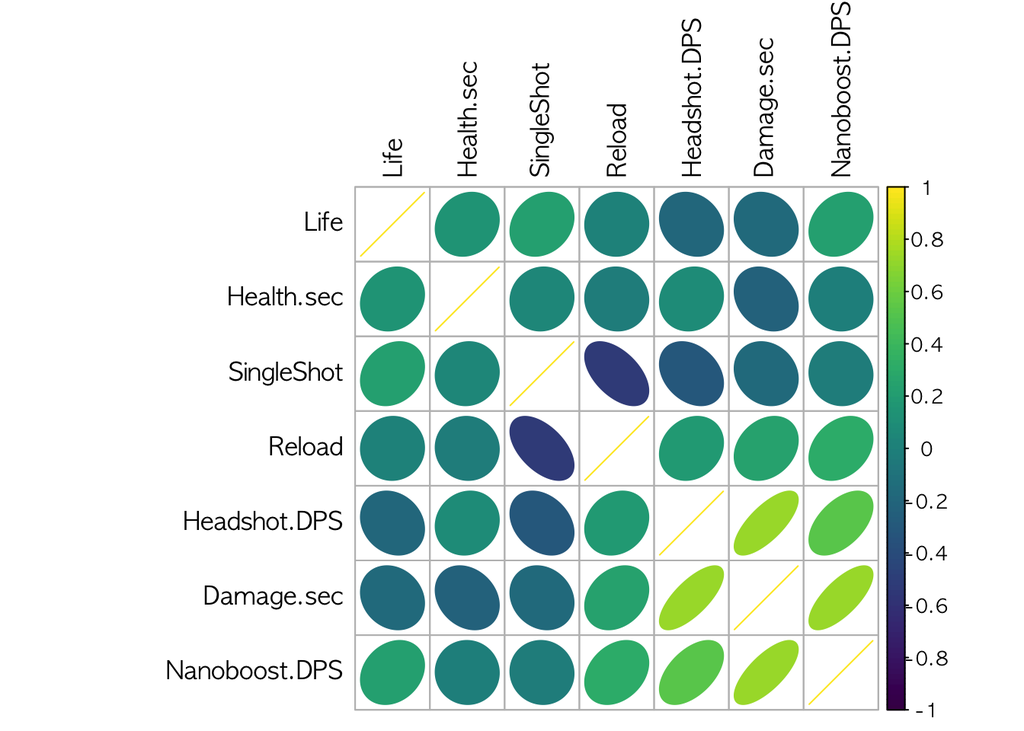

```r
corrplot(cor(res_df %>% select_if(is.numeric),method='pearson')
  ,method='ellipse',
  order="AOE",
  tl.cex=1,
  col= viridis::viridis(100),
  tl.col="black")
```

## Clustering the dataset

There are 4 classes, so lets try to clusters from 2 to 5(taking values a bit lower/higher).

```r
clusPlot<-list()
cnt<-0
for(i in 2:5){
  cnt<-cnt+1
  resClus <- kmeans(res_df %>% select_if(is.numeric), i, nstart = 1)
  clusPlot[[cnt]]<-fviz_cluster(
    resClus,
    data = res_df %>% select_if(is.numeric) ,
    geom = "point",
    stand = TRUE,
    frame.type = "norm",
    repel=T,
    show.clust.cent=F ,
    ggtheme = theme_fivethirtyeight(),
    outlier.color = "black") +
    ggtitle(paste0("# of Clusters:",i))
  }
```

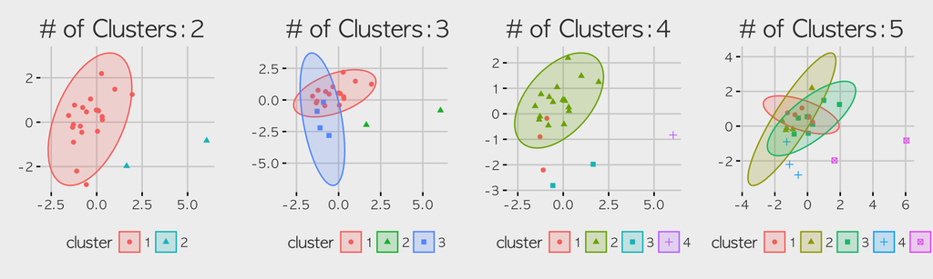

```r
do.call(grid.arrange, c(clusPlot,ncol=4))
```

- from the clusters plots, it looks like `Nclus = 3`(3 classes) would be a good value to clusters the data.

### Check: `Nclus = 3`

```r
res_clean <- as.data.frame(scale(res_df %>% select_if(is.numeric)))
ff <- dist(res_clean, method = "euclidean")
g1<-fviz_nbclust(res_clean, kmeans, method = "wss")
g2<-fviz_nbclust(res_clean, kmeans, method = "silhouette")
```

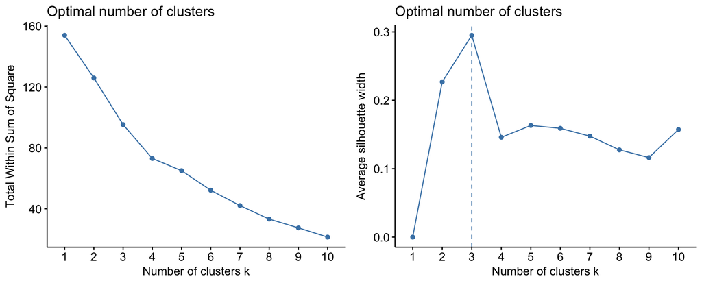

```r
grid.arrange(g1,g2,ncol=2)
```

- clustering by `silhouette` (via [http://www.sthda.com](http://www.sthda.com/english/articles/29-cluster-validation-essentials/97-cluster-validation-statistics-must-know-methods/):*The silhouette analysis measures how well an observation is clustered and it estimates the average distance between clusters. The silhouette plot displays a measure of how close each point in one cluster is to points in the neighboring clusters*) is agree with `Nclus = 3` :-)

**History :**

- *version 1: initial commit*
- *version 2: added radarcharts*
- *version 3: added dendograms*
- *version 4: added clusters section*